# Final Paper

STOR 320.01 Group 1

December 08, 2023

# INTRODUCTION

In fields like the behavioral sciences and public health, data-driven prediction can significantly change societal outcomes. Our paper analyzes two compelling questions through rigorous analysis of relevant data and thoughtful discussion, providing insights and valuable information about substance use disorders and criminal activity. Our first question aims to explore potential predictors and risk factors that predict alcohol use disorder (AUD). According to the National Institution of Health, AUD is defined as the impaired ability to control alcohol use despite associated adverse personal health or social consequences (2020). Alcohol use disorder negatively impacts the lives of those afflicted and their families. Therefore, we hope to examine predictors across categories including societal, psychological, and biological factors that may influence the development of AUD. By exploring risk factors, we aim to inform early intervention strategies to help healthcare providers improve patient outcomes, with a focus on addressing challenges faced by at-risk populations.

Existing literature indicates that alcohol consumption is correlated with an increase in the likelihood of committing violent acts (Sontate et al., 2021). Similarly, Corman and Mocan find alcohol consumption to be associated with various criminal behaviors when studying alcohol consumption and crime in New York City (2015). Although existing literature has established a correlation between alcohol consumption and crime, our research aimed to take this a step further by exploring the potential to predict criminal behavior through other variables such as demographic, employment, and other drug related factors. Being a victim of crime can have significant impacts including income loss, health issues, and social stigma (United Nations Office on Drug and Crime, 2023). As a result, reducing and preventing crime is a central goal of governments. After exploring our dataset, we decided to predict whether an individual had ever been arrested as a proxy for criminal activity. Thus, our second question focuses on determining the predictors of criminal activity involvement. Knowing what risk factors contribute to criminal activity could inform potential prevention or rehabilitation programs. Therefore, this question is related to understanding current patterns of criminal activity and holds significance in anticipating future opportunities in public safety and crime prevention across different institutions.

Taking both of our interests into consideration, the intersection of these two questions demonstrated a unique opportunity to explore and expand upon the relationship between individual health issues, such as alcohol use disorder and broader societal issues. The answers to these questions resonate with the public audience and possess the potential to enhance public health outcomes and reduce societal crime risks. Additionally, the results could provide invaluable insights for policymakers to make informed decisions in healthcare and law enforcement.

# DATA

We utilized data from the 2021 National Survey on Drug Use and Health (NSDUH), which is an annual survey conducted by the Substance Abuse and Mental Health Services Administration, a federal government agency. Established in 1971, the NSDUH stands as the most comprehensive yearly survey in the United States, focusing on alcohol use, drug use, and mental health. Its purpose is to provide essential data to government officials, lawmakers, researchers, and the public regarding the patterns of substance misuse and mental health disorders in the U.S. The Research Triangle Institute International collected the data using a combination of online and in-person questionnaires. The questionnaires garnered responses from 58,034 civilian, noninstitutionalized U.S. residents aged 12 and above. Each observation represents an individual who took the survey in 2021. The original dataset encompassed 3,003 variables, but we refined our dataset to 160 variables by selecting variables of interest to our questions. We then broke down the variables based on variables of interest corresponding to each question and subsetted those variables and excluded those with a large amount of NA values.

Our survey contains a diverse group of respondents varying in age, gender, and racial compositions. The majority of respondents fall within the younger age brackets, with 18-25 year-olds forming the largest segment (36.78%). Females are more represented than males, accounting for 67.24% of the participants. The racial composition of the respondents is predominantly White (68.62%), followed by Hispanic (14.06%), Black (7.05%), Non-Hispanic of more than one race (5.59%), Asian (2.91%), Native American (1.57%), and Native Hawaiian or Pacific Islander (0.19%). For a more comprehensive overview of the survey’s demographic landscape refer to Tables 1.1, 1.2, and 1.3 which shows the general demographic information including age, sex, gender, and race/ethnicity.

#### Figure 1.1

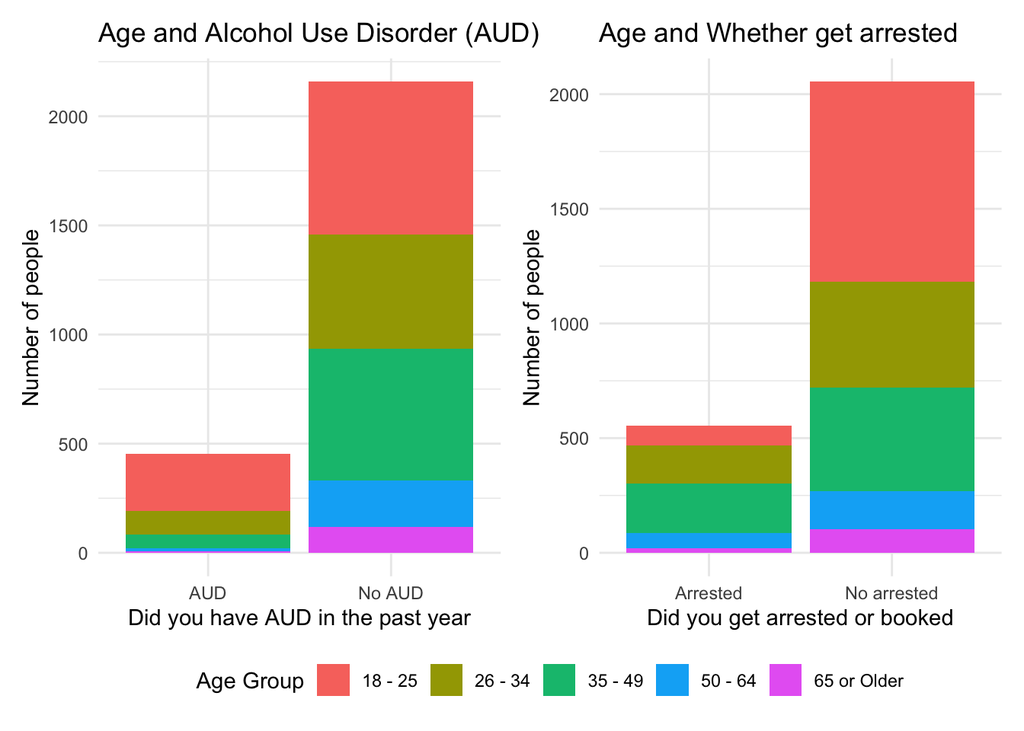

#### Figure 1.2

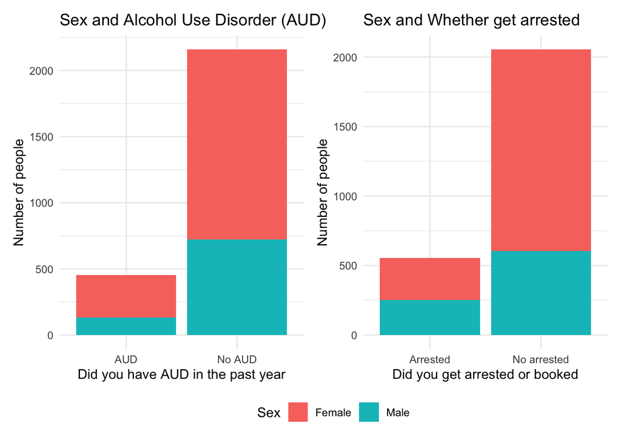

#### Figure 1.3

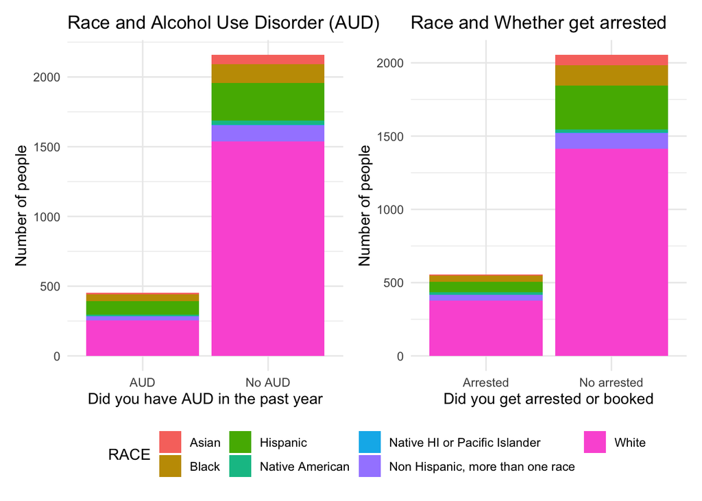

#### Table 1.1

| AGE_6_CAT | Count | Total | Prop |
| --- | --- | --- | --- |
| 18 - 25 | 960 | 2610 | 0.3678161 |
| 26 - 34 | 629 | 2610 | 0.2409962 |
| 35 - 49 | 667 | 2610 | 0.2555556 |
| 50 - 64 | 229 | 2610 | 0.0877395 |
| 65 or Older | 125 | 2610 | 0.0478927 |

#### Table 1.2

| SEX | Count | Total | Prop |
| --- | --- | --- | --- |
| Female | 1755 | 2610 | 0.6724138 |
| Male | 855 | 2610 | 0.3275862 |

#### Table 1.3

| RACE | Count | Total | Prop |
| --- | --- | --- | --- |
| Asian | 76 | 2610 | 0.0291188 |
| Black | 184 | 2610 | 0.0704981 |
| Hispanic | 367 | 2610 | 0.1406130 |
| Native American | 41 | 2610 | 0.0157088 |
| Native HI or Pacific Islander | 5 | 2610 | 0.0019157 |
| Non Hispanic, more than one race | 146 | 2610 | 0.0559387 |
| White | 1791 | 2610 | 0.6862069 |

We selected ALC_PAST_YEAR and ARRESTED_BOOK as our outcome variables to predict alcohol use disorder and criminal activity. ALC_PAST_YEAR is a dichotomous variable that indicates whether an individual met the criteria for alcohol use disorder (AUD) in the past year. Our second outcome variable, ARRESTED_BOOK, indicates whether an individual has ever been arrested or booked for legal infractions, which serves as a significant marker for criminal behavior. Table 2 includes the predictor ALC_PAST_YEAR and the variables we aim to use for its prediction. On the other hand, Table 3 focuses on the predictor ARRESTED_BOOK and the variables pertinent to predicting this outcome. Each table is carefully constructed to provide insights into these specific predictors and their associated factors for the first 12 individuals in the dataset. Lastly, Table 4 is our dataset which includes all the predictors and variables we used for both questions.

The following variables are included in the models created to answer our questions:

- AGE_6_CAT: an age variable that is recoded into 6 categories
- SEX: gender
- RACE: ethnicity group variable that is recoded into 7 categories
- RISK_FREQ: represents individuals’ frequency of risky behavior, with scores from 1 (Never) to 4 (Always);
- ALC_PER_MONTH: represents the average number of days per month that an alcoholic beverage was consumed in the past year
- AD_DPREV: is a binary variable representing if the individual had days or periods of depression or extremely sad thoughts
- PY_Adult_MDE: a binary variable representing if an experienced a major depressive episode (MDE) in the past year
- MRJ_PAST_YEAR: is a binary variable representing whether individuals had Marijuana use disorder in the past year
- ALC_Age: represents the age of first alcohol use
- Illicit_Drug_Use_Disorder: represents whether an individual had any illicit substance use disorder in the past year
- MRJ_EVER: represents if an individual ever used marijuana in their lifetime
- MRJ_Age: represents the first age of use of Marijuana
- Seek_Help_Dep: is a binary variable that represents whether individuals talked or saw a MD about depressive feelings in the past year
- DANGER_DELIGHT: represents how often an individual enjoys doing dangerous things
- TIMES_STOLE: represents how many times an individual has stolen or tried to steal anything worth more than $50 in the past year
- Adult_MDE: is a binary variable representing whether an adult ever had a major depressive episode (MDE) in their lifetime
- EMPLOYMENT_STATUS18: is a categorical variable indicating employment status of individuals over 18
- TIMES_SOLD_DRUGS: represents how many times a person sold drugs in the past year
- TIMES_ATTACKED_OTHERS: represents how many times an individual attacked someone with the intent to seriously hurt them in the past year (never, 1-2 times, 3-5 times, 6-9 times, 10 or more times)
- HER_EVER: is a binary variable indicating whether an individual ever used Heroin in their lifetime
- METH_EVER: is a binary variable indicating whether an individual ever used methamphetamine in their lifetime
- DRUG_DISORDER: is a binary variable we created to determine if a person had any drug disorder in the past year. To do this we used the variables MRJ_PAST_YEAR, ALC_PAST_YEAR, COC_PAST_YEAR, HER_PAST_YEAR, HAL_PAST_YEAR, STM_PAST_YEAR
- ANY_SUBSTANCE_FIRST_AGE: is a variable we created to determine the first age of use of any drug (i.e. If an individual first used alcohol at 6 and first used Cocaine at 20, then ANY_SUBSTANCE_FIRST_AGE is 6). To create this variable, we used the variables MRJ_FIRST_AGE, COC_FIRST_AGE, CRK_FIRST_AGE, HER_FIRST_AGE, HAL_FIRST_AGE, INHL_FIRST_AGE, METH_FIRST_AGE, OXY_FIRST_AGE

#### Table 2

| ALC_PAST_YEAR | AGE_6_CAT | SEX | RACE | RISK_FREQ | ALC_PER_MONTH | ARRESTED_BOOK | AD_DPREV | PY_Adult_MDE | MRJ_PAST_YEAR | ALC_Age | Illicit_Drug_Use_Disorder | MRJ_EVER | MRJ_Age | Seek_Help_Dep | DANGER_DELIGHT | TIMES_STOLE | Adult_MDE |
| --- | --- | --- | --- | --- | --- | --- | --- | --- | --- | --- | --- | --- | --- | --- | --- | --- | --- |
| AUD | 18 - 25 | Male | Black | Never | 4 | Arrested | 1 | 0 | 1 | 16 | 1 | 1 | 16 | 1 | Sometimes | never | 0 |
| No AUD | 35 - 49 | Female | White | Sometimes | 3 | No arrested | 1 | 0 | 0 | 15 | 0 | 1 | 24 | 0 | Seldom | never | 0 |
| No AUD | 18 - 25 | Male | White | Seldom | 5 | No arrested | 1 | 1 | 0 | 17 | 0 | 1 | 19 | 0 | Sometimes | never | 0 |
| No AUD | 65 or Older | Female | White | Seldom | 0 | No arrested | 1 | 0 | 0 | 15 | 1 | 1 | 18 | 1 | Never | never | 0 |
| No AUD | 50 - 64 | Male | White | Seldom | 0 | No arrested | 1 | 1 | 0 | 8 | 0 | 1 | 13 | 0 | Seldom | never | 0 |
| AUD | 26 - 34 | Female | Hispanic | Seldom | 4 | No arrested | 1 | 0 | 0 | 18 | 0 | 1 | 24 | 1 | Seldom | never | 0 |
| AUD | 18 - 25 | Female | White | Sometimes | 5 | No arrested | 1 | 0 | 1 | 17 | 1 | 1 | 14 | 0 | Sometimes | never | 0 |
| No AUD | 26 - 34 | Female | White | Seldom | 3 | No arrested | 1 | 0 | 0 | 18 | 0 | 1 | 24 | 0 | Never | never | 0 |
| No AUD | 18 - 25 | Female | White | Sometimes | 4 | No arrested | 1 | 1 | 0 | 15 | 0 | 1 | 15 | 1 | Sometimes | never | 0 |
| No AUD | 65 or Older | Female | White | Never | 6 | Arrested | 1 | 0 | 0 | 15 | 0 | 1 | 26 | 1 | Seldom | never | 0 |
| AUD | 26 - 34 | Female | White | Seldom | 5 | No arrested | 1 | 0 | 0 | 14 | 0 | 1 | 17 | 1 | Seldom | never | 0 |
| No AUD | 26 - 34 | Female | White | Never | 3 | No arrested | 1 | 1 | 0 | 18 | 0 | 1 | 30 | 0 | Never | never | 0 |

#### Table 3

| ARRESTED_BOOK | AGE_6_CAT | SEX | RACE | ALC_Age | MRJ_FIRST_AGE | EMPLOYMENT_STATUS18 | TIMES_SOLD_DRUGS | TIMES_STOLE | TIMES_ATTACKED_OTHERS | DANGER_DELIGHT | RISK_FREQ | MRJ_PAST_YEAR | HER_EVER | METH_EVER | DRUG_DISORDER | ANY_SUBSTANCE_FIRST_AGE |
| --- | --- | --- | --- | --- | --- | --- | --- | --- | --- | --- | --- | --- | --- | --- | --- | --- |
| Arrested | 18 - 25 | Male | Black | 16 | 16 | Part Time | never | never | never | Sometimes | Never | 1 | 0 | 0 | 1 | 16 |
| No arrested | 35 - 49 | Female | White | 15 | 24 | Full Time | never | never | never | Seldom | Sometimes | 0 | 0 | 0 | 0 | 24 |
| No arrested | 18 - 25 | Male | White | 17 | 19 | Part Time | never | never | never | Sometimes | Seldom | 0 | 0 | 0 | 0 | 19 |
| No arrested | 65 or Older | Female | White | 15 | 18 | Other (not in labor force) | never | never | never | Never | Seldom | 0 | 0 | 1 | 0 | 18 |
| No arrested | 50 - 64 | Male | White | 8 | 13 | Full Time | never | never | never | Seldom | Seldom | 0 | 1 | 1 | 0 | 13 |
| No arrested | 26 - 34 | Female | Hispanic | 18 | 24 | Full Time | never | never | never | Seldom | Seldom | 0 | 0 | 0 | 1 | 24 |
| No arrested | 18 - 25 | Female | White | 17 | 14 | Part Time | never | never | never | Sometimes | Sometimes | 1 | 0 | 1 | 1 | 14 |
| No arrested | 26 - 34 | Female | White | 18 | 24 | Full Time | never | never | never | Never | Seldom | 0 | 0 | 0 | 0 | 24 |
| No arrested | 18 - 25 | Female | White | 15 | 15 | Part Time | never | never | never | Sometimes | Sometimes | 0 | 0 | 0 | 0 | 15 |
| Arrested | 65 or Older | Female | White | 15 | 26 | Other (not in labor force) | never | never | never | Seldom | Never | 0 | 0 | 0 | 0 | 26 |
| No arrested | 26 - 34 | Female | White | 14 | 17 | Full Time | never | never | never | Seldom | Seldom | 0 | 0 | 0 | 1 | 17 |
| No arrested | 26 - 34 | Female | White | 18 | 30 | Full Time | never | never | never | Never | Never | 0 | 0 | 0 | 0 | 30 |

#### Table 4

| ALC_PAST_YEAR | ARRESTED_BOOK | AGE_6_CAT | SEX | RACE | RISK_FREQ | ALC_PER_MONTH | AD_DPREV | PY_Adult_MDE | MRJ_PAST_YEAR | ALC_Age | Illicit_Drug_Use_Disorder | MRJ_EVER | MRJ_Age | Seek_Help_Dep | DANGER_DELIGHT | TIMES_STOLE | Adult_MDE | MRJ_FIRST_AGE | EMPLOYMENT_STATUS18 | TIMES_SOLD_DRUGS | TIMES_ATTACKED_OTHERS | HER_EVER | METH_EVER | DRUG_DISORDER | ANY_SUBSTANCE_FIRST_AGE |
| --- | --- | --- | --- | --- | --- | --- | --- | --- | --- | --- | --- | --- | --- | --- | --- | --- | --- | --- | --- | --- | --- | --- | --- | --- | --- |
| AUD | Arrested | 18 - 25 | Male | Black | Never | 4 | 1 | 0 | 1 | 16 | 1 | 1 | 16 | 1 | Sometimes | never | 0 | 16 | Part Time | never | never | 0 | 0 | 1 | 16 |
| No AUD | No arrested | 35 - 49 | Female | White | Sometimes | 3 | 1 | 0 | 0 | 15 | 0 | 1 | 24 | 0 | Seldom | never | 0 | 24 | Full Time | never | never | 0 | 0 | 0 | 24 |
| No AUD | No arrested | 18 - 25 | Male | White | Seldom | 5 | 1 | 1 | 0 | 17 | 0 | 1 | 19 | 0 | Sometimes | never | 0 | 19 | Part Time | never | never | 0 | 0 | 0 | 19 |
| No AUD | No arrested | 65 or Older | Female | White | Seldom | 0 | 1 | 0 | 0 | 15 | 1 | 1 | 18 | 1 | Never | never | 0 | 18 | Other (not in labor force) | never | never | 0 | 1 | 0 | 18 |
| No AUD | No arrested | 50 - 64 | Male | White | Seldom | 0 | 1 | 1 | 0 | 8 | 0 | 1 | 13 | 0 | Seldom | never | 0 | 13 | Full Time | never | never | 1 | 1 | 0 | 13 |
| AUD | No arrested | 26 - 34 | Female | Hispanic | Seldom | 4 | 1 | 0 | 0 | 18 | 0 | 1 | 24 | 1 | Seldom | never | 0 | 24 | Full Time | never | never | 0 | 0 | 1 | 24 |
| AUD | No arrested | 18 - 25 | Female | White | Sometimes | 5 | 1 | 0 | 1 | 17 | 1 | 1 | 14 | 0 | Sometimes | never | 0 | 14 | Part Time | never | never | 0 | 1 | 1 | 14 |
| No AUD | No arrested | 26 - 34 | Female | White | Seldom | 3 | 1 | 0 | 0 | 18 | 0 | 1 | 24 | 0 | Never | never | 0 | 24 | Full Time | never | never | 0 | 0 | 0 | 24 |
| No AUD | No arrested | 18 - 25 | Female | White | Sometimes | 4 | 1 | 1 | 0 | 15 | 0 | 1 | 15 | 1 | Sometimes | never | 0 | 15 | Part Time | never | never | 0 | 0 | 0 | 15 |
| No AUD | Arrested | 65 or Older | Female | White | Never | 6 | 1 | 0 | 0 | 15 | 0 | 1 | 26 | 1 | Seldom | never | 0 | 26 | Other (not in labor force) | never | never | 0 | 0 | 0 | 26 |
| AUD | No arrested | 26 - 34 | Female | White | Seldom | 5 | 1 | 0 | 0 | 14 | 0 | 1 | 17 | 1 | Seldom | never | 0 | 17 | Full Time | never | never | 0 | 0 | 1 | 17 |
| No AUD | No arrested | 26 - 34 | Female | White | Never | 3 | 1 | 1 | 0 | 18 | 0 | 1 | 30 | 0 | Never | never | 0 | 30 | Full Time | never | never | 0 | 0 | 0 | 30 |

# RESULTS

## Predicting Alcohol Use Disorder

In examining alcohol use disorder, we aspired to find the simplest model that could reliably and accurately predict whether or not an individual in the sample had AUD in the past year. Due to our dataset’s large number of variables, selecting which variables to add to our models was the first challenge. In our initial exploratory data analysis, we observed several substance use disorders and other potential factors that could impact whether a person has a substance use disorder. The results of our data analysis guided us in choosing which variables to include in potential models. We decided to focus on alcohol use disorder as opposed to other substance use disorders because AUD is cited as the most common substance use disorder. Using the results of our exploratory data analysis and findings from the literature (Meque et. al., 2019), we selected variables relating to demographics, alcohol consumption, mental health and risky behavior. Further, we ran several Chi-square independence tests to examine the relationship between the variables we selected and our outcome variable ALC_PAST_YEAR. Then, we modified our dataset to include the variables with significance and also removed variables that had large amounts of NA’s.

To build a model to predict AUD, we ran many logistic regression models, each with a singular predictor variable. By running these models on relevant variables in the dataset, we preliminarily explored any potential associations and further narrowed down the variables to potentially include in our models. Then, based on variables we found to have a relationship with AUD, we built several logistic regression models based on themes of variables within our dataset. We also built a model using a backward stepwise selection method to obtain the “back_model” from all of the selected variables. Multiple variables related to the same overarching theme were added to the same logistic regression model. For example, we added three variables inquiring about depression to the model entitled depression_model.

[output not shown]

1. arrest_model = TIMES_STOLE + ARRESTED_BOOK
2. back_model = AGE_6_CAT + RACE + SEX + RISK_FREQ + ALC_PER_MONTH + ARRESTED_BOOK + PY_Adult_MDE + Illicit_Drug_Use_Disorder + MRJ_Age
3. depression_model = AD_DPREV + Adult_MDE + PY_Adult_MDE
4. drug_model = ALC_Age + ALC_PER_MONTH + Illicit_Drug_Use_Disorder + MRJ_EVER + MRJ_Age + MRJ_PAST_YEAR
5. mixed_model = Adult_MDE + ALC_Age + MRJ_EVER
6. risk_model = RISK_FREQ + DANGER_DELIGHT

After building several models based on themes within our dataset, we looked at the AICs and significance of variables within each model. We then narrowed our models to six potential candidates for the best model – back_model, drug_model, depression_model, risk_model, arrest_model, and mixed_model. Once we identified our best models, we ran 10-fold cross-validation on each model to determine each model’s approximate accuracy, RMSE and MAE, sensitivity, and specificity to choose the best model.

#### Table 5

| Model | RMSE | MAE | Accuracy | Sensitivity | Specificity | FPR | FNR |
| --- | --- | --- | --- | --- | --- | --- | --- |
| arrest_model | 0.3694 | 0.2267 | 0.8393 | 0.0008 | 0.9994 | 0.0006 | 0.9992 |
| back_model | 0.3651 | 0.2273 | 0.8424 | 0.0439 | 0.9587 | 0.0413 | 0.9561 |
| depression_model | 0.3396 | 0.2270 | 0.8695 | 0.0000 | 1.0000 | 0.0000 | 1.0000 |
| drug_model | 0.3401 | 0.2263 | 0.8695 | 0.0374 | 0.9632 | 0.0368 | 0.9626 |
| mixed_model | 0.3373 | 0.2267 | 0.8691 | 0.0000 | 1.0000 | 0.0000 | 1.0000 |
| risk_model | 0.3384 | 0.2268 | 0.8695 | 0.0000 | 1.0000 | 0.0000 | 1.0000 |

#### Figure 2

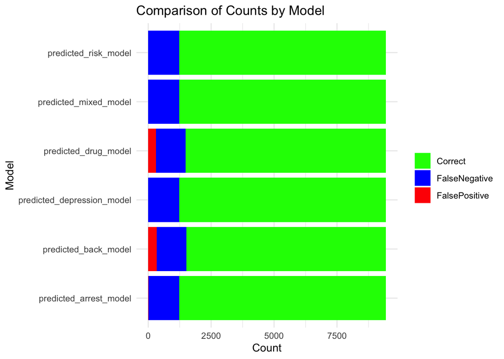

## Predicting if a Person has ever been arrested and booked for breaking the law

Since there were 160 variables in our cleaned dataset, we wanted to further narrow down the number of variables considered in predicting the outcome of ARRESTED_BOOK. To do this, we first selected 54 variables based on logical assumptions about these variables’ potential in predicting the outcome. After refining our list of variables, we categorized them into two groups based on whether they were categorical or numeric. We conducted Chi-Squared Independence tests and generated mosaic plots to assess the independence between ARRESTED_BOOK and the individual categorical variables. We show in Figure 3 an example of a mosaic plot for ARRESTED_BOOK and METH_EVER, which seem to be dependent. METH_EVER was later found to be significant in all the models we constructed. Based on the results of the mosaic plots as well as the significance of the chi-square independence tests results at the 0.05 level, we determined which numerical variables to keep for further analysis. Additionally, to examine the independence between ARRESTED_BOOK and the numeric variables, we employed data visualization techniques, using boxplots, to see whether the distribution of the numeric variable changes based on whether the outcome is zero or one. Overall, our approach to testing the relationship between the outcome and predictor variables provided us with valuable insights we needed prior to modeling.

#### Figure 3

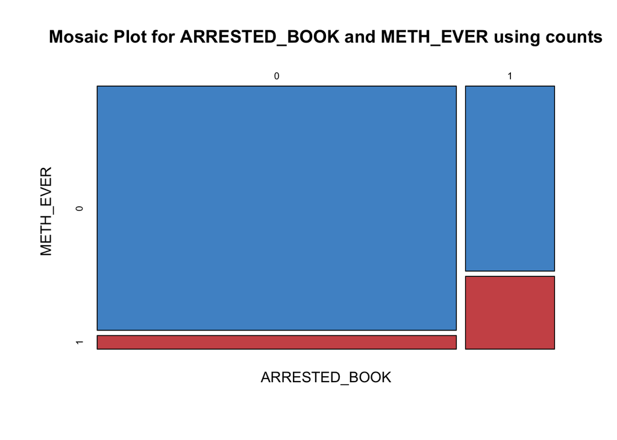

To build an accurate model, we ran seven logistic regression models to examine the relationship between our binary variable ARRESTED_BOOK and several combinations of the factor and numeric variables selected during the exploratory data analysis phase. After examining the residual deviances and the AIC from the model summaries, we also ran a 25-fold cross-validation on each of our models to assess their performance. We mainly used the results from the out-of-sample RMSE and MAE for all seven models to select the most promising ones. Model 2 and Model 5 had the lowest RMSE and MAE, as shown in Table 6. Model 2 had RMSE and MAE of 0.3750 and 0.2802, respectively, while Model 5 had RMSE and MAE of 0.3743 and 0.2791 respectively.

We created a visual with overlaid ROC plots for all our models and their respective AUCs (Figure 4). Model 2 had a slightly smaller AUC of 0.744 compared to Model 5, which had an AUC of 0.757. The AIC values, as reflected in our model summaries, were also not very different. Since the two models performed almost similarly across different metrics, we decided to select Model 2 as our model of choice as it was less complex and included less predictor variables. Our model of choice, Model2, includes the following variables: ALC_PAST_YEAR, RACE, AGE_6_CAT, EMPLOYMENT_STATUS18, TIMES_SOLD_DRUGS, TIMES_STOLE, TIMES_ATTACKED_OTHERS, DANGER_DELIGHT, RISK_FREQ, MRJ_PAST_YEAR, MRJ_EVER, HER_EVER, METH_EVER, DRUG_DISORDER.

#### Table 6

| Model | Sensitivity | Specificity | FPR | FNR | Accuracy | RMSE | MAE |
| --- | --- | --- | --- | --- | --- | --- | --- |
| model_1 | 0.5829918 | 0.8149920 | 0.1850080 | 0.4170082 | 0.7004145 | 0.4518438 | 0.4014295 |
| model_2 | 0.5829918 | 0.8149920 | 0.1850080 | 0.4170082 | 0.8117596 | 0.3749928 | 0.2802209 |
| model_3 | 0.0032258 | 0.9993654 | 0.0006346 | 0.9967742 | 0.7923424 | 0.3978076 | 0.3175548 |
| model_4 | 0.5966030 | 0.8054636 | 0.1945364 | 0.4033970 | 0.6967659 | 0.4510898 | 0.3990255 |
| model_5 | 0.2409563 | 0.9646840 | 0.0353160 | 0.7590437 | 0.8098732 | 0.3742524 | 0.2791485 |
| model_6 | 0.5700637 | 0.7922185 | 0.2077815 | 0.4299363 | 0.6833318 | 0.4524792 | 0.4050533 |
| model_7 | 0.5732484 | 0.7897351 | 0.2102649 | 0.4267516 | 0.6838350 | 0.4525737 | 0.4073333 |

#### Figure 4

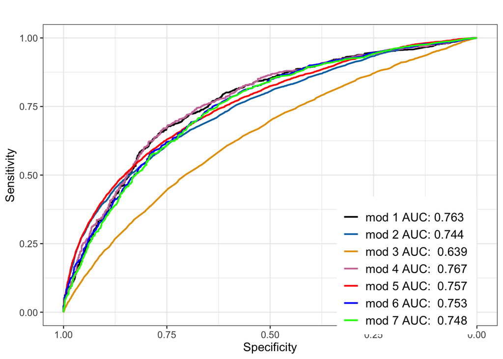

# CONCLUSION

Alcohol use disorder is a prevalent issue in America. In 2021, 29.5 million people suffered from AUD (National Institute on Alcohol Abuse and Alcoholism, 2023). AUD has crippling physical, mental, and social impacts on those who struggle with the disorder. Knowing more about what factors impact the development of alcohol use disorder can help inform prevention programs. Additionally, crime prevention is a multi-level governmental effort to reduce and deter criminals. Crime prevention programs require research on predictors of criminal activity to inform the best methods of reducing crime. By investigating predictive factors for getting arrested, our project gathers information on what risk factors are associated with crime and could inform subsequent crime prevention.

In the future, our models could be improved by using leave one out cross-validation. Due to the large number of observations in our dataset, this method of cross-validation took an excessive amount of time to run. However, running leave one out cross-validation could provide even more accurate performance measures. In the future, our results could benefit from further analysis of all 3,003 variables included in the dataset. Initially, in our exploratory data analysis, we only selected 160 variables of interest from the dataset. However, in the future, researchers could explore the potential of the other variables in the dataset to predict alcohol use disorder and criminal activity. This would help create even more accurate and robust models. It is also important to note that the data from the NSDUH survey does not include homeless populations not living in shelters, which could have significant impacts on data about drug use and health. Overall, our project has the potential to inform future crime and alcohol misuse prevention efforts. Future directions should build upon our existing models to explore even more risk factors for both AUD and crime.

## References

Corman H. & Mocan N. (2015). Alcohol Consumption, Deterrence and Crime in New York City. Journal of Labor Research. 36. 103-128. DOI: 10.1007/s12122-015-9201-4

Meque I., Salom C., Betts K.S., Alati R. (2019, May). Predictors of Alcohol Use Disorders Among Young Adults: A Systematic Review of Longitudinal Studies, Alcohol and Alcoholism. 54(3). 310–324. https://doi.org/10.1093/alcalc/agz020

National Institute on Alcohol Abuse and Alcoholism. (2023). Alcohol Use Disorder (AUD) in the United States: Age Groups and Demographic Characteristics. https://www.niaaa.nih.gov/alcohols-effects-health/alcohol-topics/alcohol-facts-and-statistics/alcohol-use-disorder-aud-united-states-age-groups-and-demographic-characteristics

National Institute on Alcohol Abuse and Alcoholism. (2020). Understanding Alcohol Use Disorder. https://www.niaaa.nih.gov/publications/brochures-and-fact-sheets/understanding-alcohol-use-disorder

Sontate K.V., Rahim K. M., Naina Mohamed I., Mohamed R.M.P., Shaikh M.F., Kamal H., Kumar J. (2021). Alcohol, Aggression, and Violence: From Public Health to Neuroscience. Frontiers in Psychology. 12:699726. doi: 10.3389/fpsyg.2021.699726.

United Nations Office on Drugs and Crime. (2019, July). Topic Two: The impact of crime, including trauma.https://www.unodc.org/e4j/en/crime-prevention-criminal-justice/module-11/key-is sues/2–the-impact-of-crime-including-trauma.html